# Beschreibende Statistik mit R

Der Datensatz *Familienstand* ist ein Beispiel für Daten, in denen bereits absolute Häufigkeiten enthalten sind. Das ist typische für Daten aus der Literatur, indem wir nicht die Urliste, sondern nur Häufigkeiten und Kennzahlen vorfinden.

In Tabelle 1, die mit der Funktion *kable* erstellt wurde, finden wir die absoluten Häufigkeiten aus der Datei:

Tabelle 1: Absolute Häufigkeiten im Datensatz Familienstand

| Ausprägungen | Häufigkeiten |
| --- | --- |
| ledig | 28 |
| verheiratet | 43 |
| verwitwet | 11 |
| geschieden | 15 |

Bei nominalen Skalen stellte sich die Frage nach der Reihenfolge im Balkendiagramm. Die folgenden Abbildungen zeigen die Alternativen, die wir betrachtet hatten. Wir teilen *ggplot* mit *stat=identity* mit, dass die Häufigkeiten bereits bestimmt sind.

Die erste Darstellung verwendet die Reihenfolge in der die Angaben in der Datei stehen:

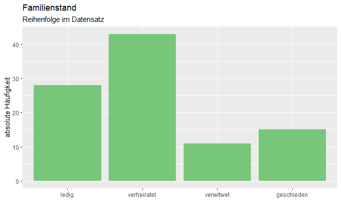

```r
# Plot absolute Häufigkeiten
ggplot(familien) +
  geom_bar(mapping=aes(x=Familienstand, y = absolut), stat="identity",
           fill=myPalette[3]) +
  scale_x_discrete(limits=c("ledig", "verheiratet", "verwitwet", "geschieden")) +
  labs(
    title="Familienstand",
    subtitle="Reihenfolge im Datensatz",
    x="",
    y="absolute Häufigkeit"
  )
```

Ordnen wir die Merkmale auf der x-Achse aufsteigend nach der absoluten Häufigkeit an erhalten wir die folgende grafische Ausgabe:

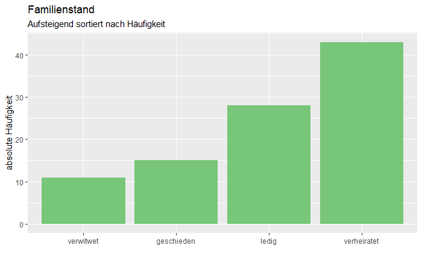

```r
ggplot(familien) +
  geom_bar(mapping=aes(x=Familienstand, y = absolut),
           stat="identity",
           fill=myPalette[3]) +
  scale_x_discrete(limits=
                     c("verwitwet", "geschieden", "ledig",
                       "verheiratet")) +
  labs(
    title="Familienstand",
    subtitle="Aufsteigend sortiert nach Häufigkeit",
    y="absolute Häufigkeit",
    x=""
  )
```

Wenn wir die Merkmale auf x-Achse absteigend nach der absoluten Häufigkeit anordnen erhalten wir die folgende grafische Ausgabe - ein Pareto-Diagramm:

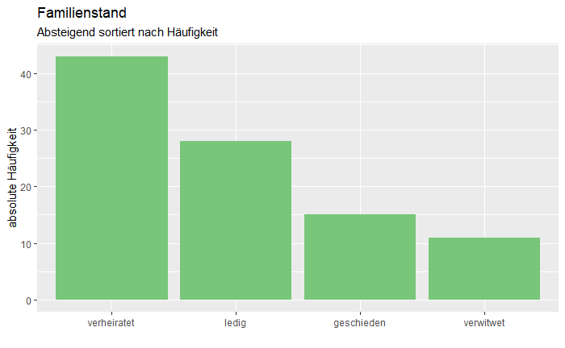

```r
ggplot(familien) +
  geom_bar(mapping=aes(x=Familienstand, y = absolut),
           stat="identity",
           fill=myPalette[3]) +
  scale_x_discrete(limits=c("verheiratet", "ledig", "geschieden", "verwitwet")) +
  labs(
    title="Familienstand",
    subtitle="Absteigend sortiert nach Häufigkeit",
    x="",
    y="absolute Häufigkeit"
  )
```

Eine neutrale Darstellung erhalten wir durch eine alphabetische Reihenfolge der Merkmale:

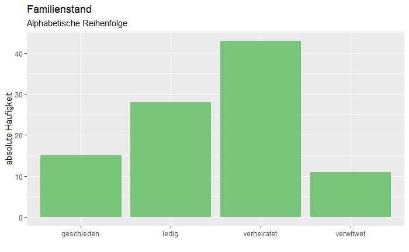

```r
ggplot(familien) +
  geom_bar(mapping=aes(x=Familienstand, y = absolut),
           stat="identity",
           fill=myPalette[3]) +
  scale_x_discrete(limits=c("geschieden", "ledig", "verheiratet", "verwitwet")) +
  labs(
    title="Familienstand",
    subtitle="Alphabetische Reihenfolge",
    x="",
    y="absolute Häufigkeit"
  )
```